# Sampling and Power

Ewy Mathé

14 August, 2019

### Goals:

1. Explore data sampling using simulated data
2. Calculate power

### Requirements:

R or Rstudio

### Input Data:

There is no data here as we are going to simulate data.

### Tips:

- If you forget how a function is used in R, type “?function” to get more information
- Ask questions!!!

### 1. Simulating data

We have discussed various sampling methods in class and will not see how to perform sampling in R.

Consider that you have a population of 2,000 individuals that were enrolled in a case-control study. The goal of the study is to identify potential biomarkers of disease, by comparing cases (disease) and controls.

The following characteristics could have a bias on study results: age, gender. location. The 2,000 individuals enrolled in the study have the following characteristics for these particular biases:

1. **age** : mean = 60, standard deviation = 10
2. **gender** : 40% female, 60% male
3. **location**: 25% individuals are from location A, 60% from location B, and 15% from location C
4. **group**: 50% are cases, and 50% are controls

Let’s go ahead an simuluate such a population of individuals. First, let’s simulate the age of these individuals, assuming that is normally distributed (Gaussian distribution), with a mean of 60 and a standard deviation of 10.

```r
set.seed(123)
age <- rnorm(2000, mean = 60, sd = 10)
```

Let’s check visually and statistically that our data is as expected:

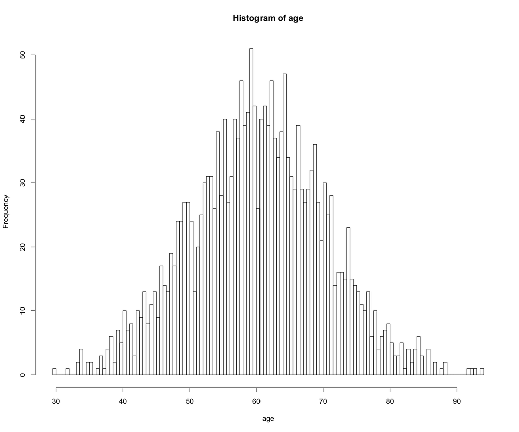

```r
hist(age, breaks = 100)
```

```r
sd(age)
```

```
## [1] 10.00561
```

```r
set.seed(234)
gender <- c(rep("F", 800), rep("M", 1200))
gender <- sample(gender, 2000, replace = FALSE)
```

Check what you’ve done:

```r
table(gender)
```

```
## gender
##    F    M
##  800 1200
```

```r
head(gender, 10)
```

```
##  [1] "M" "F" "M" "M" "F" "M" "M" "M" "M" "F"
```

```r
tail(gender, 10)
```

```
##  [1] "F" "F" "M" "F" "F" "M" "F" "F" "M" "M"
```

We can use a similar process for location, where we have 500 (25%) individuals from location A, 1,200 (60%) from location B, and 300 (15%) from location C.

```r
set.seed(345)
location <- c(rep("LocA", 500), rep("LocB", 1200), rep("LocC", 300))
location <- sample(location, 2000, replace = FALSE)
```

Let’s check

```r
table(location)
```

```
## location
## LocA LocB LocC
##  500 1200  300
```

```r
head(location, 10)
```

```
##  [1] "LocC" "LocB" "LocB" "LocC" "LocB" "LocB" "LocB" "LocA" "LocB" "LocB"
```

```r
tail(location, 10)
```

```
##  [1] "LocB" "LocB" "LocB" "LocB" "LocA" "LocC" "LocB" "LocB" "LocB" "LocB"
```

And finally, let’s simulated our 1,000 (50%) cases and 1,000 (50%) controls.

```r
set.seed(456)
caco <- c(rep("Cases", 1000), rep("Controls", 1000))
caco <- sample(caco, 2000, replace = FALSE)
table(caco)
```

```
## caco
##    Cases Controls
##     1000     1000
```

```r
head(caco)
```

```
## [1] "Controls" "Controls" "Cases"    "Cases"    "Cases"    "Controls"
```

```r
tail(caco)
```

```
## [1] "Cases"    "Controls" "Controls" "Cases"    "Controls" "Controls"
```

We can now put all these variables together and created our simulated dataset.

```r
studydata <- data.frame(age = age, gender = gender, location = location, caco = caco)
head(studydata)
```

```
##        age gender location     caco
## 1 54.39524      M     LocC Controls
## 2 57.69823      F     LocB Controls
## 3 75.58708      M     LocB    Cases
## 4 60.70508      M     LocC    Cases
## 5 61.29288      F     LocB    Cases
## 6 77.15065      M     LocB Controls
```

```r
head(table(studydata))
```

```
## [1] 0 0 1 0 0 0
```

```r
summary(studydata)
```

```
##       age        gender   location          caco
##  Min.   :29.52   F: 800   LocA: 500   Cases   :1000
##  1st Qu.:53.56   M:1200   LocB:1200   Controls:1000
##  Median :60.29            LocC: 300
##  Mean   :60.29
##  3rd Qu.:67.09
##  Max.   :93.90
```

```r
summary(studydata[which(studydata$caco == "Controls"), ])
```

```
##       age        gender  location         caco
##  Min.   :29.52   F:398   LocA:255   Cases   :   0
##  1st Qu.:54.12   M:602   LocB:608   Controls:1000
##  Median :60.35           LocC:137
##  Mean   :60.58
##  3rd Qu.:67.18
##  Max.   :92.91
```

```r
summary(studydata[which(studydata$caco == "Cases"), ])
```

```
##       age        gender  location         caco
##  Min.   :33.05   F:402   LocA:245   Cases   :1000
##  1st Qu.:53.07   M:598   LocB:592   Controls:   0
##  Median :60.09           LocC:163
##  Mean   :60.00
##  3rd Qu.:66.85
##  Max.   :93.90
```

Discussion: Is the distribution of our variables in Cases and Controls similar?

### 2. Study Design 1

From this population of 2,000 individuals that we just simulated, we have resources to run a metabolomics analysis on 1,000 individuals. After much thought of how we want to design this study, we want keep the distributions of the variables as they are originally in or study population: 1. 60% males, 40% females 2. 25% locA, 60% locB, and 15% locC 3. mean age = 60, sd = 10

We also want to have 500 (50%) cases and 500 (50%) controls.

Theoretically, if we randomly select from our original population, we would meet this criteria. Do you agree? Let’s try:

```r
cases <- studydata[which(studydata$caco == "Cases"), ]
controls <- studydata[which(studydata$caco == "Controls"), ]

mysamples <- rbind(cases[sample(1:nrow(cases), 500), ], controls[sample(1:nrow(controls),
    500), ])
dim(mysamples)
```

```
## [1] 1000    4
```

Now we can check:

```r
summary(mysamples)
```

```
##       age        gender  location         caco
##  Min.   :29.52   F:397   LocA:238   Cases   :500
##  1st Qu.:53.19   M:603   LocB:609   Controls:500
##  Median :59.88           LocC:153
##  Mean   :59.81
##  3rd Qu.:66.53
##  Max.   :93.90
```

```r
summary(mysamples[which(mysamples$caco == "Controls"), ])
```

```
##       age        gender  location         caco
##  Min.   :29.52   F:203   LocA:128   Cases   :  0
##  1st Qu.:53.92   M:297   LocB:308   Controls:500
##  Median :60.21           LocC: 64
##  Mean   :60.39
##  3rd Qu.:66.91
##  Max.   :91.84
```

```r
summary(mysamples[which(mysamples$caco == "Cases"), ])
```

```
##       age        gender  location         caco
##  Min.   :33.05   F:194   LocA:110   Cases   :500
##  1st Qu.:52.47   M:306   LocB:301   Controls:  0
##  Median :59.52           LocC: 89
##  Mean   :59.23
##  3rd Qu.:66.32
##  Max.   :93.90
```

We can also check statistically:

```r
t.test(mysamples[which(mysamples$caco == "Cases"), "age"], mysamples[which(mysamples$caco ==
    "Controls"), "age"])
```

```
##
##  Welch Two Sample t-test
##
## data:  mysamples[which(mysamples$caco == "Cases"), "age"] and mysamples[which(mysamples$caco == "Controls"), "age"]
## t = -1.7878, df = 997.52, p-value = 0.07412
## alternative hypothesis: true difference in means is not equal to 0
## 95 percent confidence interval:
##  -2.4336150  0.1132883
## sample estimates:
## mean of x mean of y
##  59.23189  60.39205
```

```r
table(studydata$gender[which(studydata$caco == "Controls")])
```

```
##
##   F   M
## 398 602
```

```r
table(studydata$gender[which(studydata$caco == "Cases")])
```

```
##
##   F   M
## 402 598
```

```r
fisher.test(matrix(c(398, 602, 402, 598), nrow = 2))
```

```
##
##  Fisher's Exact Test for Count Data
##
## data:  matrix(c(398, 602, 402, 598), nrow = 2)
## p-value = 0.8911
## alternative hypothesis: true odds ratio is not equal to 1
## 95 percent confidence interval:
##  0.8190155 1.1809865
## sample estimates:
## odds ratio
##  0.9834758
```

```r
table(studydata$location[which(studydata$caco == "Controls")])
```

```
##
## LocA LocB LocC
##  255  608  137
```

```r
table(studydata$location[which(studydata$caco == "Cases")])
```

```
##
## LocA LocB LocC
##  245  592  163
```

```r
mycontingency <- matrix(c(255, 245, 608, 592, 137, 163), nrow = 2)
colnames(mycontingency) = c("LocA", "LocB", "Loc")
rownames(mycontingency) = c("Controls", "Cases")
mycontingency
```

```
##          LocA LocB Loc
## Controls  255  608 137
## Cases     245  592 163
```

```r
fisher.test(mycontingency)
```

```
##
##  Fisher's Exact Test for Count Data
##
## data:  mycontingency
## p-value = 0.2691
## alternative hypothesis: two.sided
```

### Sample size Calculations

The package (pwr) is required to do sample calculations.

```r
if (!require(pwr)) {
    install.packages("pwr")
    library(pwr)
}
```

This R package has several functions that allow you to calculate power or sample size: 1. pwr.anova.test: if you’re doing an anova 2. pwr.r.test: if you’re doing a correlation 3. pwr.t.test: if you’re dong a t-test 4. pwr.2p.test: if you’re doing a proportion test

Please see this webpage for more information https://www.statmethods.net/stats/power.html

For all these functions, the input parameters are typically: - n: the number of observations - effect size (e.g. linear correlation coefficient, ) - signigicant level (Type I error probability, e.g. 0.05) - power - alternative: “two-sided” (default); “greater” or “less” for two-sided

*You must set one of the parameters to NULL if you want the function to calculate that parameter*

Let’s try to calculate the power when you are comparing the association of 40 observations with a categorial outcome of 5 groups using ANOVA, a Type I error probability of 0.05, and an effect size of 0.25.

```r
pwr.anova.test(f = 0.25, k = 5, n = 40, sig.level = 0.05, power = NULL)
```

```
##
##      Balanced one-way analysis of variance power calculation
##
##               k = 5
##               n = 40
##               f = 0.25
##       sig.level = 0.05
##           power = 0.809771
##
## NOTE: n is number in each group
```

If I want to calculate the number of samples I need to achieve a power of 0.95:

```r
pwr.anova.test(f = 0.25, k = 5, n = NULL, sig.level = 0.05, power = 0.95)
```

```
##
##      Balanced one-way analysis of variance power calculation
##
##               k = 5
##               n = 60.38697
##               f = 0.25
##       sig.level = 0.05
##           power = 0.95
##
## NOTE: n is number in each group
```

What if you want to test many different levels of power and see what the number of samples required is?

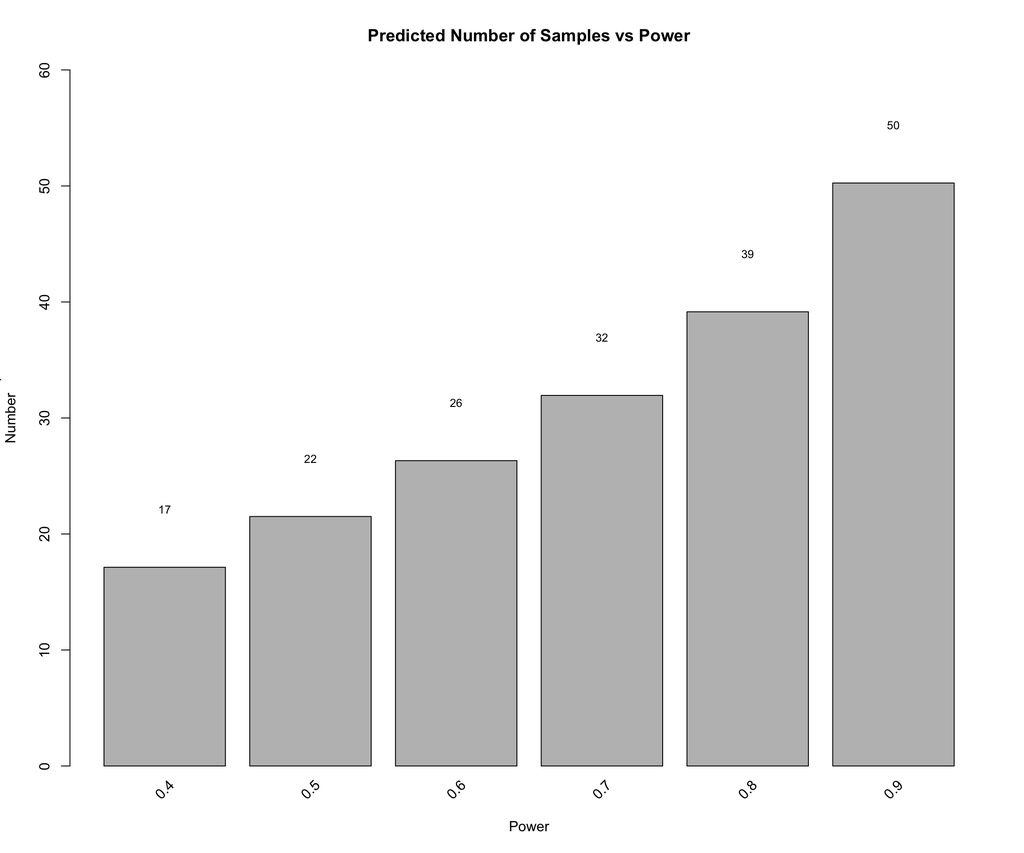

```r
powers <- seq(0.4, 0.9, 0.1)
num <- c()
for (i in 1:length(powers)) {
    temp <- pwr.anova.test(f = 0.25, k = 5, n = NULL, sig.level = 0.05, power = powers[i])$n
    num <- c(num, temp)
}

b <- barplot(num, ylab = "Predicted Sample\nNumber", xlab = "Power", ylim = c(0,
    60), main = "Predicted Number of Samples vs Power")
text(b, -2, label = powers, srt = 45, offset = 0, xpd = TRUE)
text(b, (num + 5), label = round(num, 0), xpd = TRUE, cex = 0.8)
```